# BulkRNAv3

Yu Kuan Pan

2026-03-23

# install library if not already install

un-comment this part if the packages is not installed yet

```r
#if(!requireNamespace("BiocManager", quietly = T)){
#  install.packages("BiocManager")
#  BiocManager::install(version = "3.20")
#}

# Use BiocManager to install tximport
#BiocManager::install("tximport")
#BiocManager::install("edgeR")

#BiocManager::install("GenomicFeatures")
#BiocManager::install("txdbmaker")

#if(!requireNamespace("biomaRt", quietly = T)){
#  install.packages("biomaRt")
#}

#BiocManager::install("rtracklayer")
```

## load in necessary Cell Count information

```r
library(data.table)
counts_dir<- "../../bulkRNAData/"
files <- list.files(
  counts_dir,
  pattern = "\\.counts(\\.txt)?$",
  full.names = TRUE,
  ignore.case = TRUE
)
files <- files[!grepl("Zone\\.Identifier", files, ignore.case = TRUE)]


# filename -> clean sample name
pretty_name <- function(f) {
  nm <- sub("\\.counts(\\.txt)?$", "", basename(f))  # drop extension
  nm <- sub("(_S\\d+.*)$", "", nm)                   # drop _Sxx... suffix
  nm <- sub("(\\d)percent-(\\d)$", "\\1percent\\2", nm)  # 1percent-3 -> 1percent3
  nm
}

# read one file (first two cols only), name second col as sample
read_one <- function(f) {
  dt <- fread(
    f, header = FALSE, data.table = TRUE,
    select = 1:2,                      # only first 2 columns
    col.names = c("gene", "count")     # set column names directly
  )
  dt[, gene := as.character(gene)]
  dt[, count := as.integer(count)]
  # collapse duplicates if any
  dt <- dt[, .(count = sum(count, na.rm = TRUE)), by = gene]
  setnames(dt, "count", pretty_name(f))  # rename 2nd col to sample name
  dt
}

lst <- lapply(files, read_one)

# merge by gene (union) and fill missing with 0
merged <- Reduce(function(x, y) merge(x, y, by = "gene", all = TRUE), lst)
for (j in 2:ncol(merged)) {
  set(merged, which(is.na(merged[[j]])), j, 0L)
}

count_matrix <- as.matrix(merged[, -1])
rownames(count_matrix) <- merged$gene
storage.mode(count_matrix) <- "integer"

dim(count_matrix)
```

```
## [1] 78244     9
```

```r
colnames(count_matrix)
```

```
## [1] "R179C-1percent1" "R179C-1percent2" "R179C-1percent3" "WT-1percent1"
## [5] "WT-1percent2"    "WT-1percent3"    "WT-TGFb-1"       "WT-TGFb-2"
## [9] "WT-TGFb-3"
```

```r
summary(count_matrix)
```

```
##  R179C-1percent1     R179C-1percent2     R179C-1percent3     WT-1percent1
##  Min.   :      0.0   Min.   :      0.0   Min.   :     0.0   Min.   :     0.0
##  1st Qu.:      0.0   1st Qu.:      0.0   1st Qu.:     0.0   1st Qu.:     0.0
##  Median :      0.0   Median :      0.0   Median :     0.0   Median :     0.0
##  Mean   :    181.7   Mean   :    189.7   Mean   :   167.7   Mean   :   144.8
##  3rd Qu.:      2.0   3rd Qu.:      2.0   3rd Qu.:     1.0   3rd Qu.:     1.0
##  Max.   :1019291.0   Max.   :1077732.0   Max.   :938321.0   Max.   :765584.0
##   WT-1percent2       WT-1percent3        WT-TGFb-1          WT-TGFb-2
##  Min.   :     0.0   Min.   :     0.0   Min.   :     0.0   Min.   :     0.0
##  1st Qu.:     0.0   1st Qu.:     0.0   1st Qu.:     0.0   1st Qu.:     0.0
##  Median :     0.0   Median :     0.0   Median :     0.0   Median :     0.0
##  Mean   :   168.7   Mean   :   170.8   Mean   :   167.8   Mean   :   171.3
##  3rd Qu.:     2.0   3rd Qu.:     2.0   3rd Qu.:     1.0   3rd Qu.:     1.0
##  Max.   :916510.0   Max.   :935450.0   Max.   :922654.0   Max.   :931899.0
##    WT-TGFb-3
##  Min.   :     0.0
##  1st Qu.:     0.0
##  Median :     0.0
##  Mean   :   148.3
##  3rd Qu.:     1.0
##  Max.   :800383.0
```

```r
dim(count_matrix)
```

```
## [1] 78244     9
```

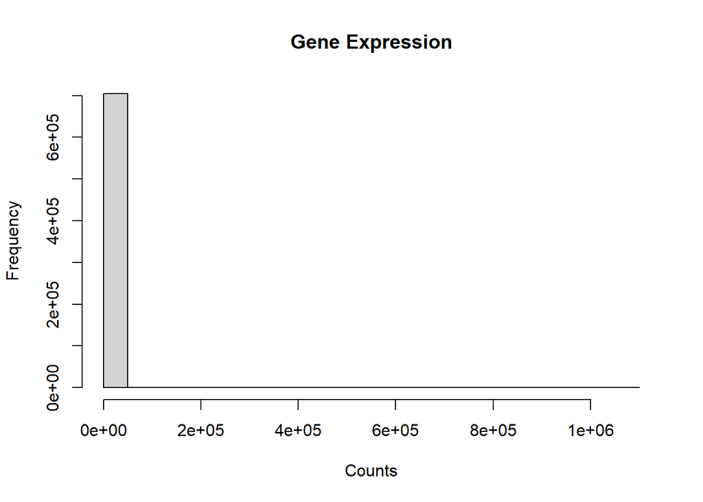

```r
hist(count_matrix, main= "Gene Expression", xlab = "Counts")
```

## Identify Marker gene with Differential Expression

```r
sample_info<- data.frame(
  sampleName = c("R179C-1percent-1_S21",
                 "R179C-1percent-2_S24",
                 "R179C-1percent-3_S27",
                 "WT-1percent-1_S19",
                 "WT-1percent-2_S22",
                 "WT-1percent-3_S25",
                 "WT-TGFb-1percent-1_S20",
                 "WT-TGFb-1percent-2_S23",
                 "WT-TGFb-1percent-3_S26"),
  condition = c("R179C", "R179C", "R179C",
                "WT", "WT", "WT",
                "TGFb", "TGFb", "TGFb"),
  replicate = c("1", "2", "3",
                "1", "2", "3",
                "1", "2", "3")

)
rownames(sample_info)<- sample_info$sampleName
```

## Data Cleaning and Preprocessing

```r
dge_all<- DGEList(counts = count_matrix)
design_filter <- model.matrix(~condition, data= sample_info)
keep<- filterByExpr(dge_all, design = design_filter, min.cont = 10)
filtered_count_matrix<- count_matrix[keep, ]
```

```r
summary(filtered_count_matrix)
```

```
##  R179C-1percent1     R179C-1percent2   R179C-1percent3     WT-1percent1
##  Min.   :      0.0   Min.   :      0   Min.   :     0.0   Min.   :     0.0
##  1st Qu.:     58.0   1st Qu.:     61   1st Qu.:    53.0   1st Qu.:    48.0
##  Median :    269.0   Median :    288   Median :   254.0   Median :   214.0
##  Mean   :    992.1   Mean   :   1036   Mean   :   915.9   Mean   :   790.8
##  3rd Qu.:    773.0   3rd Qu.:    824   3rd Qu.:   721.0   3rd Qu.:   602.0
##  Max.   :1019291.0   Max.   :1077732   Max.   :938321.0   Max.   :765584.0
##   WT-1percent2       WT-1percent3        WT-TGFb-1          WT-TGFb-2
##  Min.   :     0.0   Min.   :     0.0   Min.   :     0.0   Min.   :     0.0
##  1st Qu.:    56.0   1st Qu.:    58.0   1st Qu.:    46.0   1st Qu.:    55.0
##  Median :   258.0   Median :   263.0   Median :   226.0   Median :   252.0
##  Mean   :   921.4   Mean   :   932.9   Mean   :   916.6   Mean   :   935.8
##  3rd Qu.:   724.0   3rd Qu.:   741.0   3rd Qu.:   660.8   3rd Qu.:   714.0
##  Max.   :916510.0   Max.   :935450.0   Max.   :922654.0   Max.   :931899.0
##    WT-TGFb-3
##  Min.   :     0.0
##  1st Qu.:    47.0
##  Median :   214.0
##  Mean   :   809.8
##  3rd Qu.:   611.0
##  Max.   :800383.0
```

```r
dim(filtered_count_matrix)
```

```
## [1] 14298     9
```

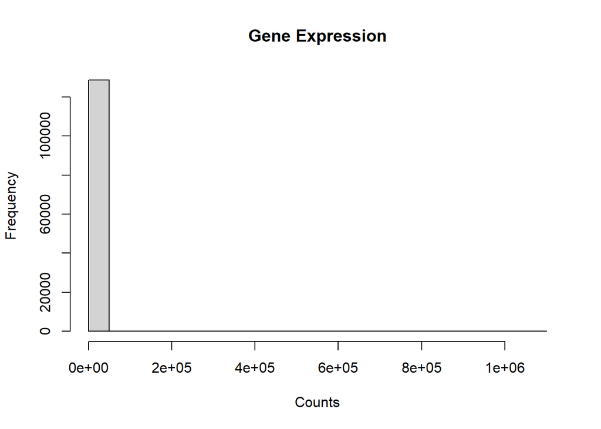

```r
hist(filtered_count_matrix, main= "Gene Expression", xlab = "Counts")
```

```r
count_matrix<- filtered_count_matrix
```

## Exchange gene id with actual gene name

this chunk will be checked later since some of the gene aren’t able to matched with the ID use control shift c to comment all chunk

```r
stopifnot(all(count_matrix == round(count_matrix)))
counts<- as.matrix(count_matrix)

# strip version suffix from Ensembl IDs
ens <- sub("\\.\\d+$", "", rownames(counts))

mapfile<- "../../mm10_ens2symbol.tsv"

map<- read.delim(mapfile, header = F, sep = "\t",
                 col.names =
                   c("ensembl_gene_id", "gene_name"),
                 stringsAsFactors = F)

# check for both gene ID match ens
matched_ids <- intersect(ens, map$ensembl_gene_id)
length(matched_ids)
```

```
## [1] 13764
```

```r
head(matched_ids, 10)
```

```
##  [1] "ENSMUSG00000000001" "ENSMUSG00000000028" "ENSMUSG00000000031"
##  [4] "ENSMUSG00000000037" "ENSMUSG00000000056" "ENSMUSG00000000058"
##  [7] "ENSMUSG00000000078" "ENSMUSG00000000085" "ENSMUSG00000000088"
## [10] "ENSMUSG00000000093"
```

```r
# Remove ".5" or ".16" etc.
ens_ids <- sub("\\.\\d+$", "", rownames(count_matrix))
rownames(count_matrix) <- ens_ids

# make sure column names in map are: ensembl_gene_id, gene_name
colnames(map) <- c("ensembl_gene_id", "gene_name")

# remove duplicated Ensembl IDs in the map
map <- map[!duplicated(map$ensembl_gene_id), ]

# create a vector for quick lookup
gene_names <- setNames(map$gene_name, map$ensembl_gene_id)

# replace Ensembl IDs by matched gene name
matched_genes <- gene_names[rownames(count_matrix)]

# any NA means not found → keep Ensembl ID
matched_genes[is.na(matched_genes)] <- rownames(count_matrix)[is.na(matched_genes)]

# assign new names
rownames(count_matrix) <- matched_genes
colnames(count_matrix)<- rownames(sample_info)
```

## creating DESeq object for Differential Expression

```r
colnames(count_matrix)<- rownames(sample_info)
dds<- DESeqDataSetFromMatrix(countData = count_matrix,
                             colData = sample_info,
                             design = ~ condition)
dds$condition <- relevel(dds$condition, ref = "WT")

dds<- DESeq(dds)
# pairwise
res_R179C_vs_WT   <- results(dds, contrast = c("condition","R179C","WT"))
res_TGFb_vs_WT    <- results(dds, contrast = c("condition","TGFb","WT"))
```

```r
# global “compare all together” (ANOVA-like)
dds_lrt <- DESeq(dds, test="LRT", reduced=~1)
```

```
## found already estimated dispersions, replacing these
```

```r
res_LRT <- results(dds_lrt)   # genes that vary across WT/R179C/TGFb
```

## PCA and sample distance heatmap

```r
set.seed(123)
# subset to only R179C and WT samples for clearer visualization
samples_to_keep<- sample_info$condition %in% c("R179C", "WT")
dds_subset <- dds[, samples_to_keep]
dds_subset$condition <- factor(dds_subset$condition, levels = c("WT", "R179C"))  # drop unused levels
vsd_subset<- vst(dds_subset, blind = FALSE)
dds<- dds_subset
vsd<- vsd_subset
mat<- assay(vsd_subset)
#vsd <- vst(dds, blind = FALSE)
#mat <- assay(vsd)

# PCA with sample labels
p <- plotPCA(vsd, intgroup = "condition", returnData = TRUE)
```

```
## using ntop=500 top features by variance
```

[figure not shown]

```r
percentVar <- round(100 * attr(p, "percentVar"))
ggplot(p, aes(PC1, PC2, color = condition, label = rownames(p))) +
  geom_point(size = 3) + geom_text(nudge_y = 1.5, size = 3) +
  xlab(paste0("PC1: ", percentVar[1], "%")) +
  ylab(paste0("PC2: ", percentVar[2], "%")) +
  ggtitle("PCA (vst) — all samples")
```

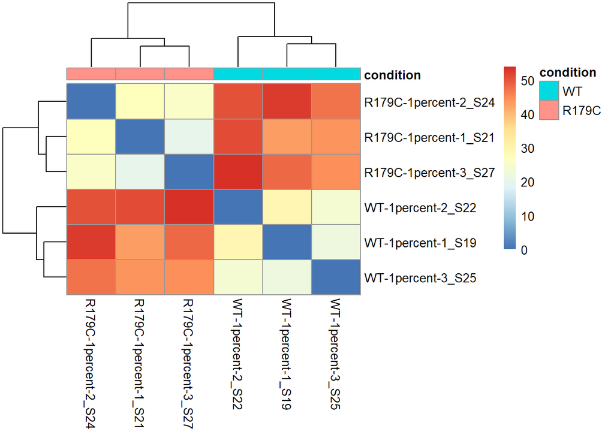

```r
# Sample distance heatmap
d <- dist(t(assay(vsd)))
pheatmap(as.matrix(d), annotation_col=as.data.frame(colData(dds)[,"condition",drop=FALSE]))
```

### R179C vs wildType

```r
sig_R179C_vs_WT<- subset(res_R179C_vs_WT, padj < 0.05
                         & abs(log2FoldChange) > 1)
sig_R179C_vs_WT<- as.data.frame(sig_R179C_vs_WT[order(sig_R179C_vs_WT$log2FoldChange, decreasing = T),])
nrow(sig_R179C_vs_WT)
```

```
## [1] 1558
```

```r
head(sig_R179C_vs_WT, 10)
```

```
##                      baseMean log2FoldChange     lfcSE     stat       pvalue
## Palmd               36.969339       8.161365 1.4862749 5.491155 3.993142e-08
## AI838599            71.392396       7.713236 0.8808501 8.756581 2.012614e-18
## Cntnap4             11.123932       7.478809 1.3974721 5.351670 8.714628e-08
## Mx1                 22.486199       7.466011 1.4451770 5.166156 2.389567e-07
## Sfta3-ps             8.189243       7.034255 1.3927779 5.050522 4.406046e-07
## Il33               266.193280       6.830864 0.9616164 7.103523 1.216163e-12
## ENSMUSG00000140545  29.396449       6.798414 1.4646941 4.641525 3.458470e-06
## Abcc9                5.762560       6.499516 1.4339417 4.532622 5.825606e-06
## Wt1                 27.055189       6.309327 0.9396175 6.714782 1.883470e-11
## Lrrc3b               4.828311       6.274317 1.4698129 4.268786 1.965394e-05
##                            padj
## Palmd              8.330219e-07
## AI838599           2.357398e-16
## Cntnap4            1.680594e-06
## Mx1                4.169343e-06
## Sfta3-ps           7.220458e-06
## Il33               5.911216e-11
## ENSMUSG00000140545 4.432425e-05
## Abcc9              6.983885e-05
## Wt1                7.455618e-10
## Lrrc3b             2.027832e-04
```

remove the argument for log2FC > 1

```r
sig_pval_R179C_vs_WT<- subset(res_R179C_vs_WT, padj < 0.05)
sig_pval_R179C_vs_WT<- as.data.frame(sig_pval_R179C_vs_WT[order(sig_pval_R179C_vs_WT$log2FoldChange, decreasing = T),])
nrow(sig_pval_R179C_vs_WT)
```

```
## [1] 3961
```

```r
#write.csv(sig_pval_R179C_vs_WT, "./bulkRNA3repRes/sig_pval_R179C_vs_WT.csv")
```

### validate gene list result with previous study WT vs R179C

```r
sheets<- excel_sheets("../../bulkRNARefence1Replicate/DEGs.xlsx")
print(sheets)
```

```
## [1] "1vs2" "3vs4" "1vs3" "2vs4"
```

```r
R179C_WT_ref<- read_excel(
  "../../bulkRNARefence1Replicate/DEGs.xlsx",
           sheet = "1vs2") %>%
  select(geneName, log2FC, Probability)
nrow(R179C_WT_ref)
```

```
## [1] 1223
```

```r
head(R179C_WT_ref, 10)
```

```
## # A tibble: 10 × 3
##    geneName log2FC Probability
##    <chr>     <dbl>       <dbl>
##  1 Xlr3b      7.71       0.997
##  2 Pof1b      7.40       0.995
##  3 Tspan8     7.36       1.000
##  4 Moxd1      7.35       0.999
##  5 Muc5b      7.07       0.999
##  6 Muc5ac     6.97       0.989
##  7 Hmcn1      6.94       0.988
##  8 Cpxm2      6.85       0.986
##  9 Gucy1a3    6.82       1.000
## 10 Adgrf5     6.82       1.000
```

#### check common gene

```r
InterGene<- intersect(rownames(sig_R179C_vs_WT), R179C_WT_ref$geneName )
nrow(sig_R179C_vs_WT[InterGene,])
```

```
## [1] 432
```

```r
head(sig_R179C_vs_WT[InterGene,],10)
```

```
##           baseMean log2FoldChange     lfcSE      stat       pvalue         padj
## Palmd     36.96934       8.161365 1.4862749  5.491155 3.993142e-08 8.330219e-07
## Cntnap4   11.12393       7.478809 1.3974721  5.351670 8.714628e-08 1.680594e-06
## Il33     266.19328       6.830864 0.9616164  7.103523 1.216163e-12 5.911216e-11
## Cpxm2     15.89604       6.121333 1.1671310  5.244770 1.564776e-07 2.866751e-06
## Ces1g    270.46549       6.011954 0.5697667 10.551606 4.993637e-26 1.321464e-23
## Moxd1   1184.91203       5.965244 0.8532287  6.991377 2.722007e-12 1.242731e-10
## Apob      19.59992       5.637288 1.2193382  4.623236 3.778002e-06 4.765018e-05
## Nrxn1     38.52710       5.368862 0.6077347  8.834219 1.007996e-18 1.201747e-16
## Kcnk3     81.90383       5.273469 0.5676055  9.290728 1.532368e-20 2.488357e-18
## Aldh1a2  138.01280       5.087116 0.5513768  9.226206 2.803882e-20 4.355160e-18
```

```r
write.csv(as.data.frame(sig_R179C_vs_WT), "./sig_R179C_vs_WT.csv")
```

```r
save(sig_R179C_vs_WT, file = "./sig_R179C_vs_WT.RData")
```

## Create MA & volcano plot

#### R179C vs WT

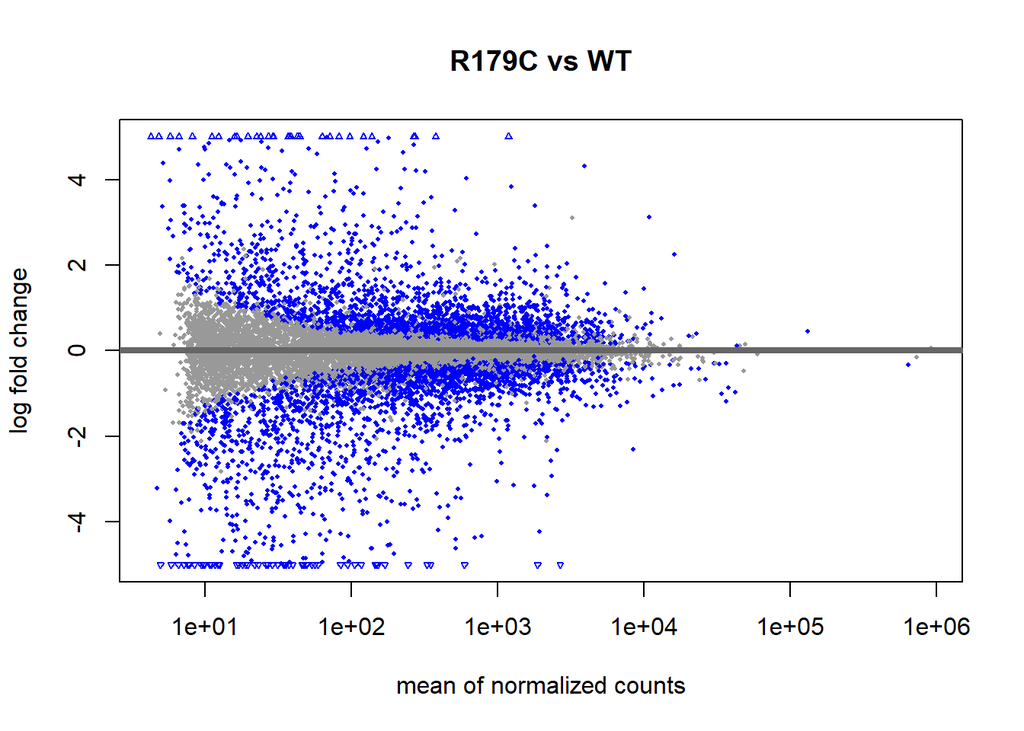

```r
DESeq2::plotMA(res_R179C_vs_WT, main = "R179C vs WT", ylim = c(-5,5),
       alpa=0.05)
```

### Volcano plot R179C vs WT

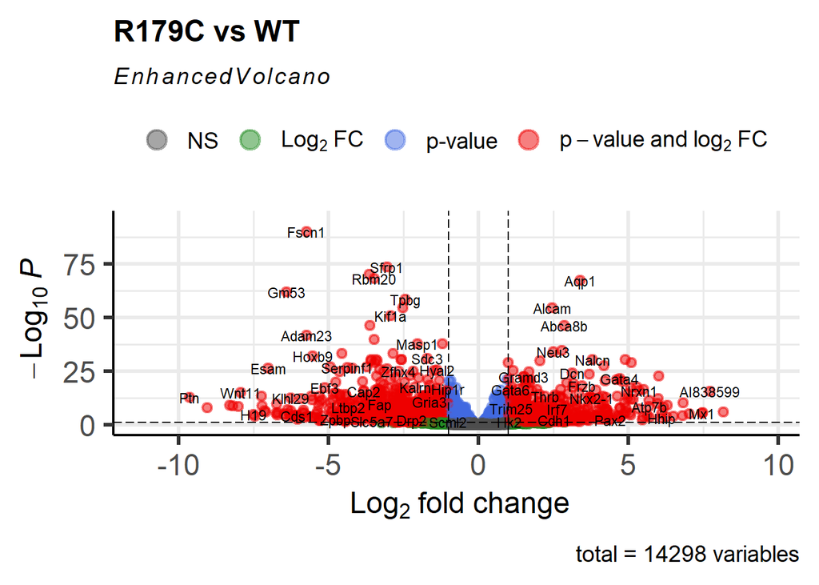

```r
#devtools::install_github('kevinblighe/EnhancedVolcano')
library(EnhancedVolcano)
EnhancedVolcano(res_R179C_vs_WT,
                lab = rownames(res_R179C_vs_WT),
                x = 'log2FoldChange',
                y = 'padj',
                title = 'R179C vs WT',
                pCutoff = 0.05,
                FCcutoff = 1.0,
                pointSize = 2.0,
                labSize = 3.0)
```

[figure not shown]

```r
# 1. Filter for robust genes (baseMean > 600)
res_df <- as.data.frame(res_R179C_vs_WT)
res_robust <- res_df[which(res_df$baseMean > 600), ]

# 2. Identify Top 40 for each condition (R179C up and WT up/R179C down)
# Sorting by Log2FC for magnitude
top40_R179C <- head(rownames(res_robust[order(res_robust$log2FoldChange, decreasing = TRUE), ]), 40)
top40_WT    <- head(rownames(res_robust[order(res_robust$log2FoldChange, decreasing = FALSE), ]), 40)

# 3. Combine them and explicitly add Prune2
# unique() prevents errors if Prune2 is already in the top 40
genes_to_label <- unique(c(top40_R179C, top40_WT))

# 4. Generate the Volcano Plot
library(EnhancedVolcano)
EnhancedVolcano(res_R179C_vs_WT,
                lab = rownames(res_R179C_vs_WT),
                selectLab = genes_to_label, # This is the key line
                x = 'log2FoldChange',
                y = 'padj',
                title = 'R179C vs WT (Robust Genes & Prune2)',
                pCutoff = 0.05,
                FCcutoff = 1.0,
                pointSize = 2.0,
                labSize = 3.0,
                drawConnectors = TRUE,   # Adds lines from label to point
                widthConnectors = 0.5,
                colConnectors = 'black')
```

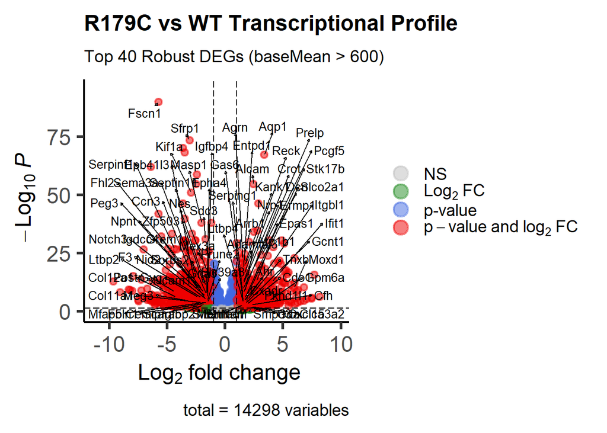

```r
# 1. Identify the Top 40 robust genes per side
res_df <- as.data.frame(res_R179C_vs_WT)
res_robust <- res_df[which(res_df$baseMean > 600 & !is.na(res_df$padj)), ]

top40_up <- head(rownames(res_robust[order(res_robust$log2FoldChange, decreasing = TRUE), ]), 40)
top40_down <- head(rownames(res_robust[order(res_robust$log2FoldChange, decreasing = FALSE), ]), 40)

# 2. label list
my_labels <- unique(c(top40_up, top40_down))

# 3. Generate the Volcano Plot (Standard Colors)
library(EnhancedVolcano)
EnhancedVolcano(res_df,
                lab = rownames(res_df),
                x = 'log2FoldChange',
                y = 'padj',
                selectLab = my_labels,
                title = 'R179C vs WT Transcriptional Profile',
                subtitle = 'Top 40 Robust DEGs (baseMean > 600)',
                pCutoff = 0.05,
                FCcutoff = 1.0,
                # Standard Colors: NS=grey, Log2FC=green, p-value=blue, both=red
                col = c('grey', 'forestgreen', 'royalblue', 'red2'),
                pointSize = 2.0,
                labSize = 3.5,
                # Ensure all 81 names are visible
                max.overlaps = Inf,
                drawConnectors = TRUE,
                widthConnectors = 0.5,
                colConnectors = 'black',
                legendPosition = 'right',
                gridlines.major = FALSE,
                gridlines.minor = FALSE)
```

## plot count example

use Prune2 gene as example

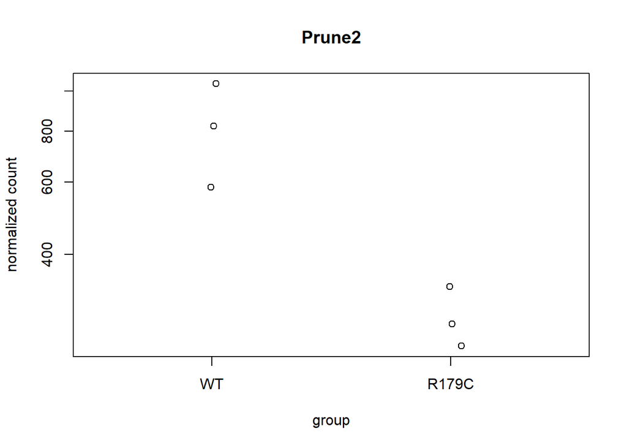

```r
plotCounts(dds, gene="Prune2", intgroup="condition")
```

## Heatmap of top 20 DEGs

#### R179C vs WT

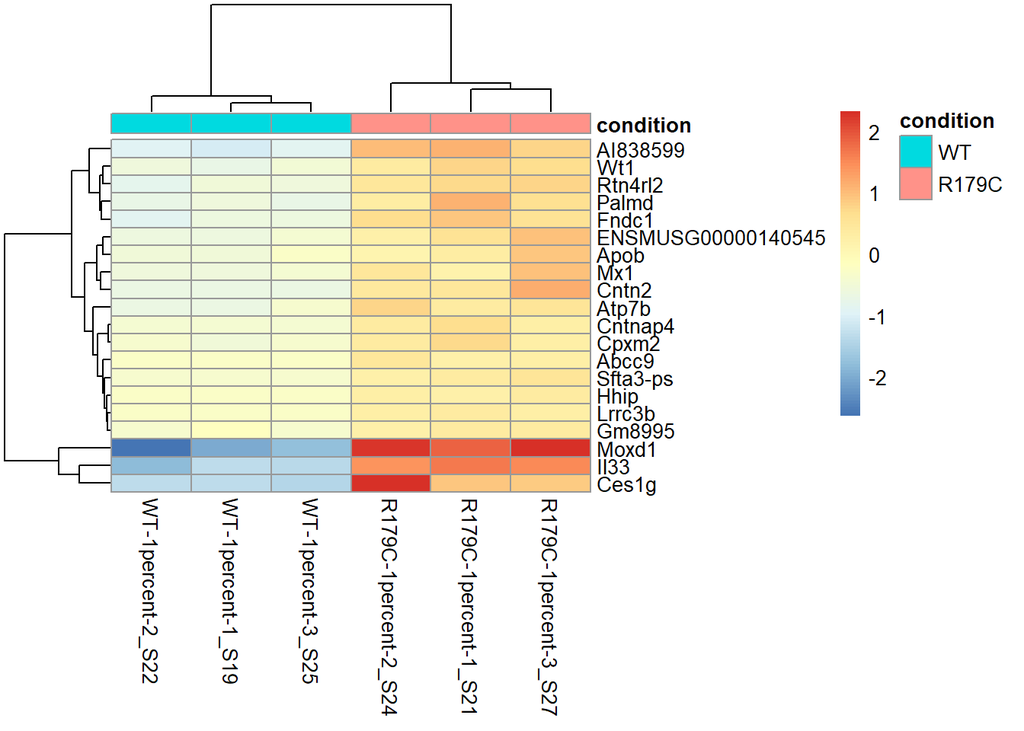

```r
top20_R179C_vs_WT <- head(rownames(sig_R179C_vs_WT), 20)
mat_R179C_vs_WT <- assay(vst(dds))[top20_R179C_vs_WT, ]
mat_R179C_vs_WT <- mat_R179C_vs_WT - rowMeans(mat_R179C_vs_WT)
pheatmap(mat_R179C_vs_WT, annotation_col = as.data.frame(colData(dds)[, "condition", drop=F]))
```

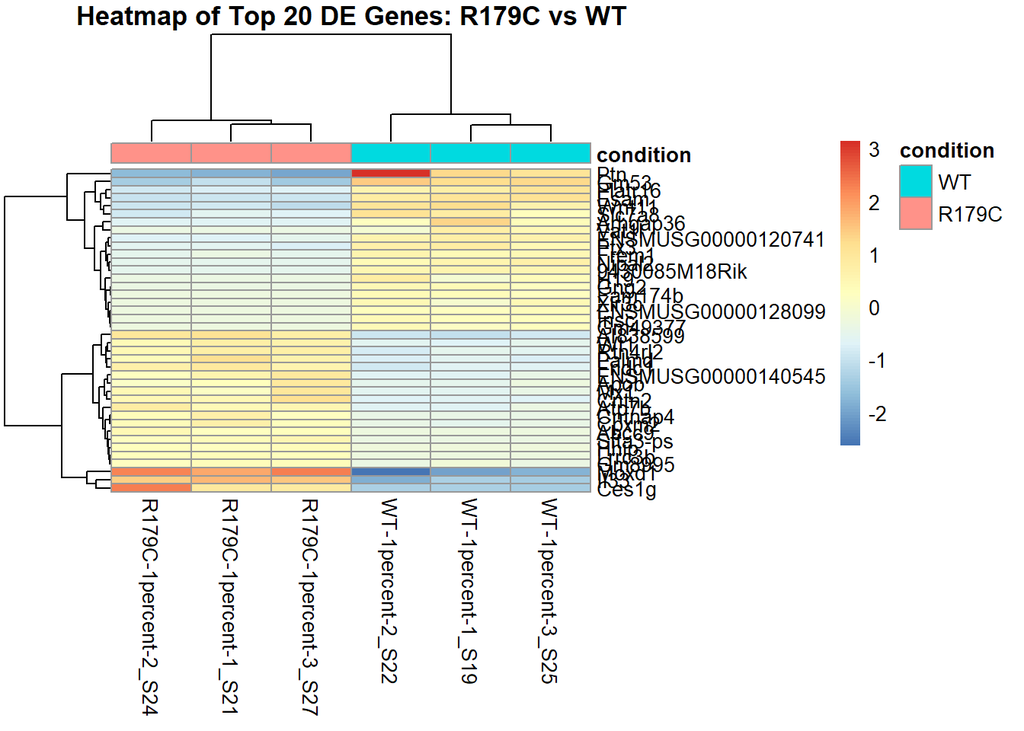

```r
# R179C upregulated genes
#r179c_up <- subset(res_R179C_vs_WT, log2FoldChange > 1 & padj < 0.05)
#top20_R179C <- head(rownames(r179c_up[order(r179c_up$padj), ]), 20)
top20_R179C <- head(rownames(sig_R179C_vs_WT), 20)

# WT upregulated genes
#wt_up <- subset(res_R179C_vs_WT, log2FoldChange < -1  & padj < 0.05)
#top20_WT <- head(rownames(wt_up[order(wt_up$padj), ]), 20)

# Already filtered for padj < 0.05 and |log2FC| > 1
sig_R179C_vs_WT_WT <- sig_R179C_vs_WT[order(sig_R179C_vs_WT$log2FoldChange), ]
top20_WT <- head(rownames(sig_R179C_vs_WT_WT), 20)

# Combine gene set
combined_genes <- c(top20_R179C, top20_WT)

# Subset samples to R179C and WT only
selected_samples <- colData(dds)$condition %in% c("R179C", "WT")

mat_combined <- assay(vst(dds))[combined_genes, selected_samples]
mat_combined <- mat_combined - rowMeans(mat_combined)

annotation <- as.data.frame(colData(dds)[selected_samples, "condition", drop=FALSE])

pheatmap(mat_combined,
         annotation_col = annotation,
         cluster_rows = TRUE,
         cluster_cols = TRUE,
         show_rownames = TRUE,
         main = "Heatmap of Top 20 DE Genes: R179C vs WT")
```

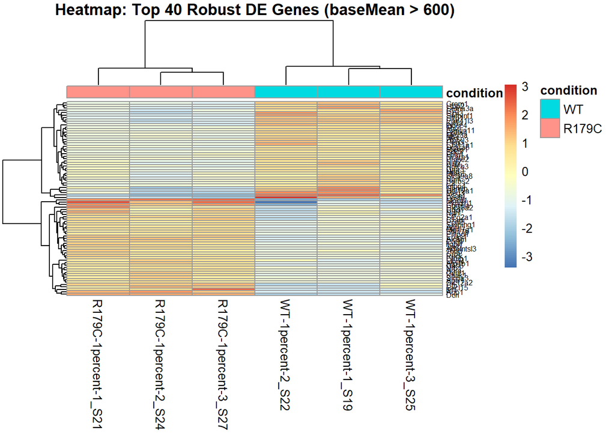

```r
# 1. Filter for Robustness (baseMean > 600)
# Assuming sig_R179C_vs_WT is your dataframe of significant results
sig_robust <- sig_R179C_vs_WT[sig_R179C_vs_WT$baseMean > 600, ]

# 2. Extract Top 40 R179C Enriched (Highest Log2FC)
# We sort by log2FoldChange decreasing to get the most upregulated
top40_R179C <- head(rownames(sig_robust[order(sig_robust$log2FoldChange, decreasing = TRUE), ]), 40)

# 3. Extract Top 40 WT Enriched (Lowest Log2FC / Most Repressed)
# We sort by log2FoldChange increasing to get the most downregulated
top40_WT <- head(rownames(sig_robust[order(sig_robust$log2FoldChange, decreasing = FALSE), ]), 40)

# 4. Combine and Ensure Prune2 is included
# Since Prune2 is around rank 40, we add it explicitly to be safe
combined_genes <- unique(c(top40_R179C, top40_WT, "Prune2"))

# 5. Subset samples correctly (Ensure 3 replicates only)
# We filter for condition AND ensure we only take replicates 1, 2, and 3
selected_samples <- colData(dds)$condition %in% c("R179C", "WT") &
                    colData(dds)$replicate %in% c("1", "2", "3")

# 6. Prepare Matrix (Using VST values)
# We use the subset of samples we just defined
vst_mat <- assay(vst(dds))
mat_combined <- vst_mat[combined_genes, selected_samples]

# Row-center the data (Z-score style) to highlight differences
mat_combined <- mat_combined - rowMeans(mat_combined)

# 7. Create Heatmap
annotation <- as.data.frame(colData(dds)[selected_samples, "condition", drop=FALSE])

pheatmap(mat_combined,
         annotation_col = annotation,
         cluster_rows = TRUE,
         cluster_cols = TRUE,
         show_rownames = TRUE,
         fontsize_row = 6, # Smaller font since we have 80+ genes
         main = "Heatmap: Top 40 Robust DE Genes (baseMean > 600)")
```

## pathway analysis function

```r
suppressMessages({
  library(clusterProfiler)
  library(ReactomePA)
  library(org.Mm.eg.db)
  library(ggplot2)
  library(openxlsx)
})
Pathway_Enrich <- function(sig_gene_list,
                           condition = "Sample",
                           method = c("KEGG", "Reactome"),
                           p_cut = 0.05,
                           showCategory = 10,
                           output_prefix = "Pathway") {

  method <- match.arg(method)  # restrict to KEGG or Reactome

  message(paste0("Running ", method, " enrichment for ", condition, " ..."))

  # ---- Convert gene symbols to Entrez IDs
  gene_symbols <- rownames(sig_gene_list)
  entrez_ids <- suppressMessages(
    bitr(gene_symbols, fromType = "SYMBOL", toType = "ENTREZID", OrgDb = org.Mm.eg.db)
  )

  if (is.null(entrez_ids) || nrow(entrez_ids) == 0) {
    warning("No valid Entrez IDs found for enrichment.")
    return(NULL)
  }

  # ---- Run enrichment analysis
  enrich_res <- switch(
    method,
    KEGG = suppressMessages(
      enrichKEGG(gene = entrez_ids$ENTREZID,
                 organism = "mmu",
                 pvalueCutoff = p_cut)
    ),
    Reactome = suppressMessages(
      enrichPathway(gene = entrez_ids$ENTREZID,
                    organism = "mouse",
                    pvalueCutoff = p_cut)
    )
  )

  if (is.null(enrich_res) || nrow(as.data.frame(enrich_res)) == 0) {
    message("No significant enrichment found.")
    return(NULL)
  }

  # ---- Plot results
  print(
    dotplot(enrich_res, showCategory = showCategory) +
      ggtitle(paste(method, "Pathway Enrichment -", condition))
  )

  # ---- Convert to readable format (add gene symbols)
  readable_res <- suppressMessages(
    setReadable(enrich_res, OrgDb = org.Mm.eg.db, keyType = "ENTREZID")
  )

  result_df <- as.data.frame(readable_res)

  # ---- Save output to Excel
  output_file <- paste0(output_prefix, "_", condition, "_", method, "_pathway.xlsx")
  openxlsx::write.xlsx(result_df, output_file, overwrite = TRUE)
  message(paste("Saved:", output_file))

  return(result_df)
}
```

```r
# Run KEGG for R179C
R179C_KEGG<- Pathway_Enrich(sig_R179C_vs_WT, condition = "R179C", method = "KEGG")
```

```
## Running KEGG enrichment for R179C ...
```

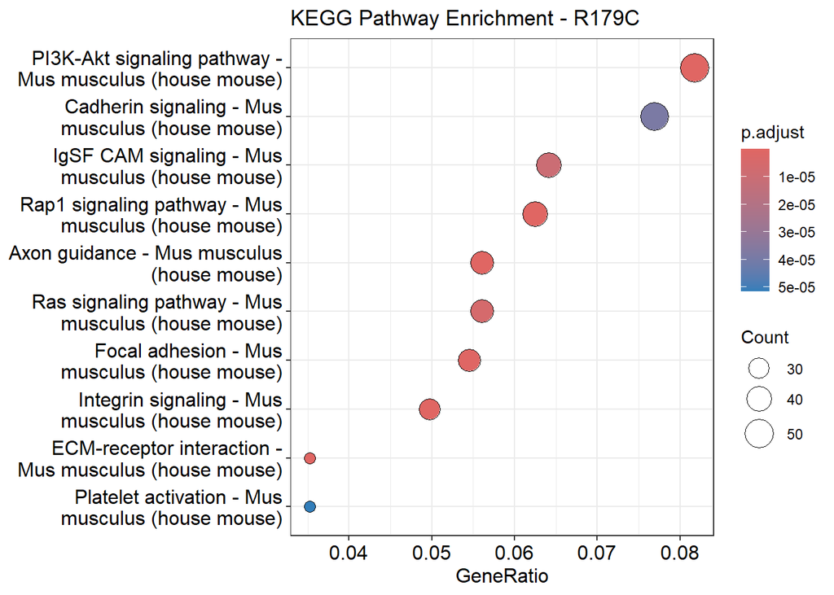

```
## Saved: Pathway_R179C_KEGG_pathway.xlsx
```

```r
R179C_KEGG
```

[output not shown]

[output cut: 337 more lines]

```
## mmu00980    11
## mmu00601     6
## mmu05144    10
## mmu05410    13
## mmu04350    14
## mmu04625    14
## mmu04725    14
## mmu05417    22
## mmu05211    10
## mmu04666    12
## mmu00260     7
## mmu00350     7
## mmu04926    15
## mmu05168    21
## mmu00512     6
```

```r
# Run Reactome for R179C
R179C_Reactome<- Pathway_Enrich(sig_R179C_vs_WT, condition = "R179C", method = "Reactome")
```

```
## Running Reactome enrichment for R179C ...
```

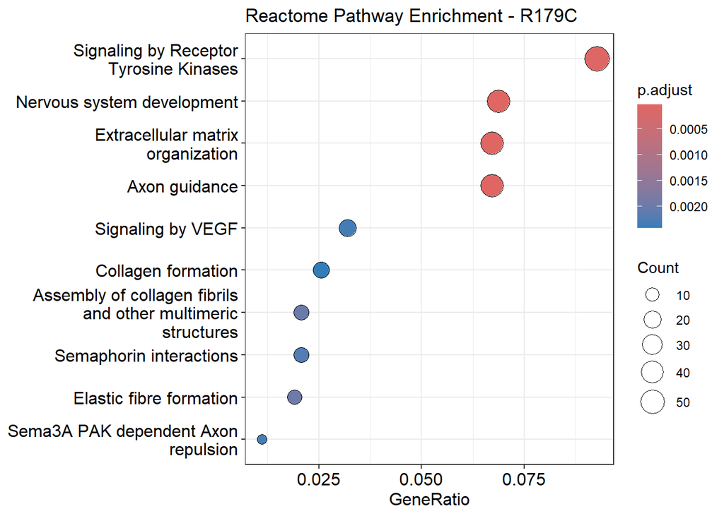

```
## Saved: Pathway_R179C_Reactome_pathway.xlsx
```

```r
R179C_Reactome
```

```
##                          ID
## R-MMU-9675108 R-MMU-9675108
## R-MMU-1474244 R-MMU-1474244
## R-MMU-422475   R-MMU-422475
## R-MMU-9006934 R-MMU-9006934
## R-MMU-1566948 R-MMU-1566948
## R-MMU-2022090 R-MMU-2022090
## R-MMU-373755   R-MMU-373755
## R-MMU-399954   R-MMU-399954
## R-MMU-194138   R-MMU-194138
## R-MMU-1474290 R-MMU-1474290
## R-MMU-399956   R-MMU-399956
## R-MMU-2129379 R-MMU-2129379
## R-MMU-5173214 R-MMU-5173214
## R-MMU-216083   R-MMU-216083
## R-MMU-114604   R-MMU-114604
## R-MMU-3928663 R-MMU-3928663
## R-MMU-202733   R-MMU-202733
## R-MMU-1650814 R-MMU-1650814
## R-MMU-3000178 R-MMU-3000178
## R-MMU-5173105 R-MMU-5173105
## R-MMU-4420097 R-MMU-4420097
## R-MMU-8948216 R-MMU-8948216
## R-MMU-399955   R-MMU-399955
## R-MMU-3000171 R-MMU-3000171
## R-MMU-381426   R-MMU-381426
## R-MMU-9013149 R-MMU-9013149
##                                                                                                                               Description
## R-MMU-9675108                                                                                                  Nervous system development
## R-MMU-1474244                                                                                           Extracellular matrix organization
## R-MMU-422475                                                                                                                Axon guidance
## R-MMU-9006934                                                                                      Signaling by Receptor Tyrosine Kinases
## R-MMU-1566948                                                                                                     Elastic fibre formation
## R-MMU-2022090                                                                Assembly of collagen fibrils and other multimeric structures
## R-MMU-373755                                                                                                      Semaphorin interactions
## R-MMU-399954                                                                                          Sema3A PAK dependent Axon repulsion
## R-MMU-194138                                                                                                            Signaling by VEGF
## R-MMU-1474290                                                                                                          Collagen formation
## R-MMU-399956                                                                                                    CRMPs in Sema3A signaling
## R-MMU-2129379                                                                                    Molecules associated with elastic fibres
```

[output cut: 80 more lines]

```
## R-MMU-2129379    10
## R-MMU-5173214    10
## R-MMU-216083     15
## R-MMU-114604     10
## R-MMU-3928663     7
## R-MMU-202733     20
## R-MMU-1650814    13
## R-MMU-3000178    11
## R-MMU-5173105    18
## R-MMU-4420097    17
## R-MMU-8948216    10
## R-MMU-399955      5
## R-MMU-3000171     9
## R-MMU-381426     19
## R-MMU-9013149    23
```

## Pathway analysis

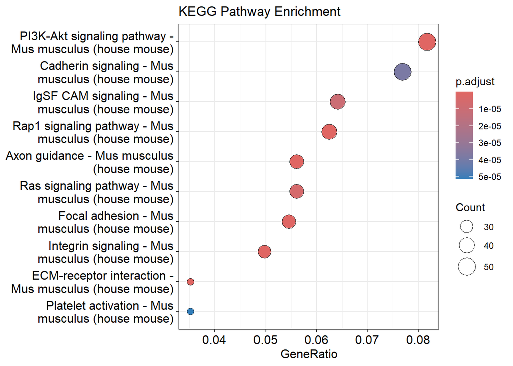

[output not shown]

[output cut: 337 more lines]

```
## mmu00980    11
## mmu00601     6
## mmu05144    10
## mmu05410    13
## mmu04350    14
## mmu04625    14
## mmu04725    14
## mmu05417    22
## mmu05211    10
## mmu04666    12
## mmu00260     7
## mmu00350     7
## mmu04926    15
## mmu05168    21
## mmu00512     6
```

```r
## R179C vs WT Pathway Analysis
library(clusterProfiler)
library(org.Mm.eg.db)
#library(enrichplot)

# Convert gene symbols to Entrez IDs
gene_symbols <- rownames(sig_R179C_vs_WT)
entrez_ids <- bitr(gene_symbols, fromType = "SYMBOL",
                   toType = "ENTREZID",
                   OrgDb = org.Mm.eg.db)
## KEGG Pathway Analysis
if(!is.null(entrez_ids) && nrow(entrez_ids) > 0){
  kegg_enrich <- enrichKEGG(gene = entrez_ids$ENTREZID,
                            organism = 'mmu',
                            pvalueCutoff = 0.05)
  if(!is.null(kegg_enrich) && nrow(as.data.frame(kegg_enrich)) > 0){
    # Visualize KEGG results
    print(dotplot(kegg_enrich,
                  showCategory=10) +
            ggtitle("KEGG Pathway Enrichment"))
    # Convert KEGG pathway IDs to readable gene symbol
    kegg_genes <- setReadable(kegg_enrich,
                                    OrgDb = org.Mm.eg.db,
                                    keyType = "ENTREZID")
    print(as.data.frame(kegg_genes))

  } else {
    print("No significant KEGG pathways found.")
  }
} else {
  print("No valid Entrez IDs found for KEGG analysis.")
}
```

return gene list that classified under each go term with all three category, Biological_Process, Molecular_Function, Cellular_Component

```r
library(openxlsx)
library(dplyr)
library(clusterProfiler)

export_top_GO_terms <- function(GO_result_list,
                                condition_name,
                                top_n = NULL,       # If NULL, export all dotplot-visible terms
                                output_prefix = "GO_Results",
                                remove_empty = TRUE # Option B: filter out terms without geneID
                                ) {

  ontologies <- c("Biological_Process", "Molecular_Function", "Cellular_Component")

  for (ont in ontologies) {

    if (!ont %in% names(GO_result_list)) {
      message(paste("Skipping", ont, "- not found in provided list."))
      next
    }

    go_obj <- GO_result_list[[ont]]$result
    go_expanded <- GO_result_list[[ont]]$expanded

    if (is.null(go_obj) || is.null(go_expanded)) {
      message(paste("Skipping", ont, "- missing data."))
      next
    }

    # convert enrichResult object to data frame
    go_df <- as.data.frame(go_obj)

    # ---- If top_n not specified, use same terms as dotplot (default = 10 or fewer)
    if (is.null(top_n)) {
      # Extract top categories shown in dotplot (based on p.adjust & gene ratio)
      top_terms <- go_df %>%
        arrange(p.adjust, desc(GeneRatio)) %>%
        slice_head(n = 10)
    } else {
      top_terms <- go_df %>%
        arrange(p.adjust) %>%
        slice_head(n = top_n)
    }

    filtered_expanded <- go_expanded %>%
      filter(ID %in% top_terms$ID)

    # ---- Option B: Remove terms with empty or NA geneID
    if (remove_empty) {
      filtered_expanded <- filtered_expanded %>%
        filter(!is.na(geneID), geneID != "")
    }

    # ---- Create Excel workbook
    wb <- createWorkbook()

    for (go_id in unique(filtered_expanded$ID)) {
      sub_df <- filtered_expanded %>% filter(ID == go_id)
      term_name <- unique(sub_df$Description)[1]

      # Clean & shorten Excel sheet name
      safe_name <- paste0(
        gsub("[^A-Za-z0-9]", "_", go_id), "_",
        gsub("[^A-Za-z0-9]", "_", substr(term_name, 1, 15))
      )
      safe_name <- substr(safe_name, 1, 31)

      addWorksheet(wb, safe_name)
      writeData(wb, safe_name, sub_df)
    }

    # ---- Save workbook per ontology
    filename <- paste0(output_prefix, "_", condition_name, "_", ont, "_filtered.xlsx")
    saveWorkbook(wb, filename, overwrite = TRUE)

    message(paste("saved:", filename))
  }
}
```

#### Add additional replicate to the data (4th replicate)

```r
library(dplyr)
library(purrr)

# 1. Define folder path - ensure this matches your folder name exactly
data_dir <- "../../bulkRNARefence1Replicate/Counts/"

# 2. Identify the count files
# Updated pattern to be more flexible (looks for 'counts' anywhere in the name)
count_files <- list.files(path = data_dir,
                          pattern = "counts",
                          full.names = TRUE)

# Filter out the 'Identifier' files manually to be safe
count_files <- count_files[!grepl("Identifier", count_files)]

# --- SAFETY CHECK ---
if (length(count_files) == 0) {
  stop("No files found! Check if './Count' is the correct folder and contains the .txt files.")
}

# 3. Read and Merge
counts_combined <- count_files %>%
  map(function(file) {
    # Using read.table; check if your files use tabs or commas
    df <- read.table(file, header = TRUE, sep = "\t", stringsAsFactors = FALSE)

    # Standardize the first column name for joining
    colnames(df)[1] <- "GeneID"

    # Extract a clean sample name from the file path
    sample_id <- basename(file) %>% gsub("_counts.*", "", .)
    colnames(df)[2] <- sample_id

    return(df)
  }) %>%
  reduce(full_join, by = "GeneID")

# 4. Final Formatting
rownames(counts_combined) <- counts_combined$GeneID
counts_combined <- as.matrix(counts_combined[,-1])

# View result
print(paste("Successfully merged", ncol(counts_combined), "files."))
```

```
## [1] "Successfully merged 3 files."
```

```r
#head(counts_combined)
```

## Identify Marker gene with Differential Expression

```r
 sample_info_4rep<- data.frame(
  sampleName = c("R179C-1percent-1",
                 "R179C-1percent-2",
                 "R179C-1percent-3",
                 "R179C-1percent-4",
                 "WT-1percent-1",
                 "WT-1percent-2",
                 "WT-1percent-3",
                 "WT-1percent-4",
                 "WT-TGFb-1percent-1",
                 "WT-TGFb-1percent-2",
                 "WT-TGFb-1percent-3",
                 "WT-TGFb-1percent-4"),
  batch = c("Batch1","Batch1","Batch1","Batch2",
                       "Batch1","Batch1","Batch1","Batch2",
                       "Batch1","Batch1","Batch1","Batch2"),
  condition = c("R179C", "R179C", "R179C", "R179C",
                "WT", "WT", "WT", "WT",
                "TGFb", "TGFb", "TGFb", "TGFb"),
  replicate = c("1", "2", "3", "4",
                "1", "2", "3", "4",
                "1", "2", "3", "4")

)
rownames(sample_info_4rep)<- sample_info_4rep$sampleName
```

## Replace Ensembl ID with gene symbol for the new replicate data

```r
# 1. Prepare counts_combined (Ensembl to Symbol Mapping)
# ---------------------------------------------------
# Strip version suffix (e.g., .15) from Ensembl IDs in the new replicate data
ens_ids <- sub("\\.\\d+$", "", rownames(counts_combined))
rownames(counts_combined) <- ens_ids

# Load your mapping file (ensure path is correct relative to your .Rmd)
mapfile <- "../../mm10_ens2symbol.tsv"
map <- read.delim(mapfile, header = FALSE, sep = "\t",
                  col.names = c("ensembl_gene_id", "gene_name"),
                  stringsAsFactors = FALSE)

# Remove duplicates in the map file to prevent 1-to-many expansion
map <- map[!duplicated(map$ensembl_gene_id), ]

# Create a lookup vector for quick translation
gene_lookup <- setNames(map$gene_name, map$ensembl_gene_id)

# Perform the mapping
matched_symbols <- gene_lookup[rownames(counts_combined)]

# If no symbol found in the TSV, keep the original Ensembl ID to avoid losing data
matched_symbols[is.na(matched_symbols)] <- rownames(counts_combined)[is.na(matched_symbols)]

# CRITICAL: Handle duplicate gene symbols (e.g., Symbol.1, Symbol.2)
# This prevents the "duplicate 'row.names' are not allowed" error in R matrices
rownames(counts_combined) <- make.unique(as.character(matched_symbols))
```

## Consistant rowname (gene id)

since there are only 5 common gene appear check the id by strip where everything after the dot would be remove this process won’t actually affect the gene name

```r
# Strip the version (anything after the first dot) from rownames
strip_ver <- function(x) sub("\\..*$", "", x)

ids_a <- strip_ver(rownames(count_matrix))
ids_b <- strip_ver(rownames(counts_combined))

length(intersect(ids_a, ids_b))
```

```
## [1] 13765
```

```r
# Standardize rownames to versionless before merging
rownames(count_matrix)   <- ids_a
rownames(counts_combined) <- ids_b
colnames(counts_combined)<- c("R179C-1percent4", "WT-1percent4", "WT-TGFb-4")
```

```r
count_matrix_ordered <- merge(count_matrix, counts_combined, by = "row.names", all.x = TRUE)

# Clean up Row Names
rownames(count_matrix_ordered) <- count_matrix_ordered$Row.names
count_matrix_ordered$Row.names <- NULL

# Handle Missing Data (NAs)
# If a gene was in your original set but not the new one, we fill with 0
# This prevents DESeq2 from crashing due to missing values
count_matrix_ordered[is.na(count_matrix_ordered)] <- 0

# Final Formatting
count_matrix_ordered <- round(as.matrix(count_matrix_ordered))


desired_order <- c(
  "R179C-1percent-1_S21", "R179C-1percent-2_S24", "R179C-1percent-3_S27", "R179C-1percent4", # R179C Group
  "WT-1percent-1_S19", "WT-1percent-2_S22", "WT-1percent-3_S25", "WT-1percent4",             # WT Group
  "WT-TGFb-1percent-1_S20", "WT-TGFb-1percent-2_S23", "WT-TGFb-1percent-3_S26", "WT-TGFb-4" # TGFb Group
)

# 2. Reorder the Matrix columns
count_matrix_ordered <- count_matrix_ordered[, desired_order]
```

```r
dim(count_matrix_ordered)
```

```
## [1] 14298    12
```

```r
summary(count_matrix_ordered)
```

```
##  R179C-1percent-1_S21 R179C-1percent-2_S24 R179C-1percent-3_S27
##  Min.   :      0.0    Min.   :      0      Min.   :     0.0
##  1st Qu.:     58.0    1st Qu.:     61      1st Qu.:    53.0
##  Median :    269.0    Median :    288      Median :   254.0
##  Mean   :    992.1    Mean   :   1036      Mean   :   915.9
##  3rd Qu.:    773.0    3rd Qu.:    824      3rd Qu.:   721.0
##  Max.   :1019291.0    Max.   :1077732      Max.   :938321.0
##  R179C-1percent4   WT-1percent-1_S19  WT-1percent-2_S22  WT-1percent-3_S25
##  Min.   :      0   Min.   :     0.0   Min.   :     0.0   Min.   :     0.0
##  1st Qu.:     52   1st Qu.:    48.0   1st Qu.:    56.0   1st Qu.:    58.0
##  Median :    291   Median :   214.0   Median :   258.0   Median :   263.0
##  Mean   :   1078   Mean   :   790.8   Mean   :   921.4   Mean   :   932.9
##  3rd Qu.:    833   3rd Qu.:   602.0   3rd Qu.:   724.0   3rd Qu.:   741.0
##  Max.   :1277095   Max.   :765584.0   Max.   :916510.0   Max.   :935450.0
##   WT-1percent4       WT-TGFb-1percent-1_S20 WT-TGFb-1percent-2_S23
##  Min.   :      0.0   Min.   :     0.0       Min.   :     0.0
##  1st Qu.:     49.0   1st Qu.:    46.0       1st Qu.:    55.0
##  Median :    287.0   Median :   226.0       Median :   252.0
##  Mean   :   1133.8   Mean   :   916.6       Mean   :   935.8
##  3rd Qu.:    863.8   3rd Qu.:   660.8       3rd Qu.:   714.0
##  Max.   :1221887.0   Max.   :922654.0       Max.   :931899.0
##  WT-TGFb-1percent-3_S26   WT-TGFb-4
##  Min.   :     0.0       Min.   :      0
##  1st Qu.:    47.0       1st Qu.:     39
##  Median :   214.0       Median :    238
##  Mean   :   809.8       Mean   :   1152
##  3rd Qu.:   611.0       3rd Qu.:    791
##  Max.   :800383.0       Max.   :1006387
```

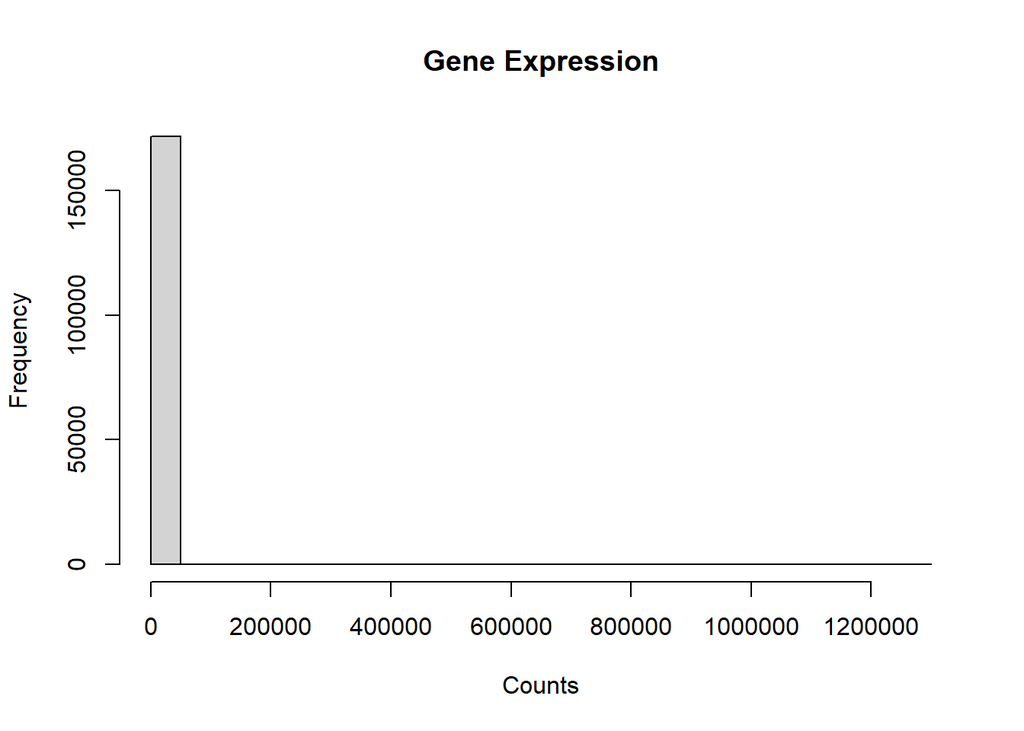

```r
hist(count_matrix_ordered, main= "Gene Expression", xlab = "Counts")
```

```r
colnames(count_matrix_ordered)<- rownames(sample_info_4rep)
dds_4rep<- DESeqDataSetFromMatrix(countData = count_matrix_ordered,
                             colData = sample_info_4rep,
                             design = ~ batch + condition)
dds_4rep$condition <- relevel(dds_4rep$condition, ref = "WT")

dds_4rep<- DESeq(dds_4rep)
```

```r
# pairwise
res_R179C_vs_WT_4rep   <- results(dds_4rep, contrast = c("condition","R179C","WT"))
```

## PCA and sample distance heatmap

```r
set.seed(123)

vsd_4rep <- vst(dds_4rep, blind = FALSE)
mat_4rep <- assay(vsd_4rep)

# This keeps all 8 replicates (4 vs 4) but ignores TGFb
vsd_4rep <- vsd_4rep[, vsd_4rep$condition %in% c("R179C", "WT")]
# Drop unused factor levels so the legend is clean
vsd_4rep$condition <- droplevels(vsd_4rep$condition)


# PCA with sample labels
p <- plotPCA(vsd_4rep, intgroup = "condition", returnData = TRUE)
```

```
## using ntop=500 top features by variance
```

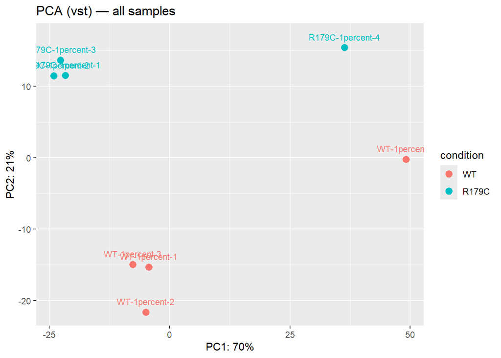

```r
percentVar <- round(100 * attr(p, "percentVar"))
ggplot(p, aes(PC1, PC2, color = condition, label = rownames(p))) +
  geom_point(size = 3) + geom_text(nudge_y = 1.5, size = 3) +
  xlab(paste0("PC1: ", percentVar[1], "%")) +
  ylab(paste0("PC2: ", percentVar[2], "%")) +
  ggtitle("PCA (vst) — all samples")
```

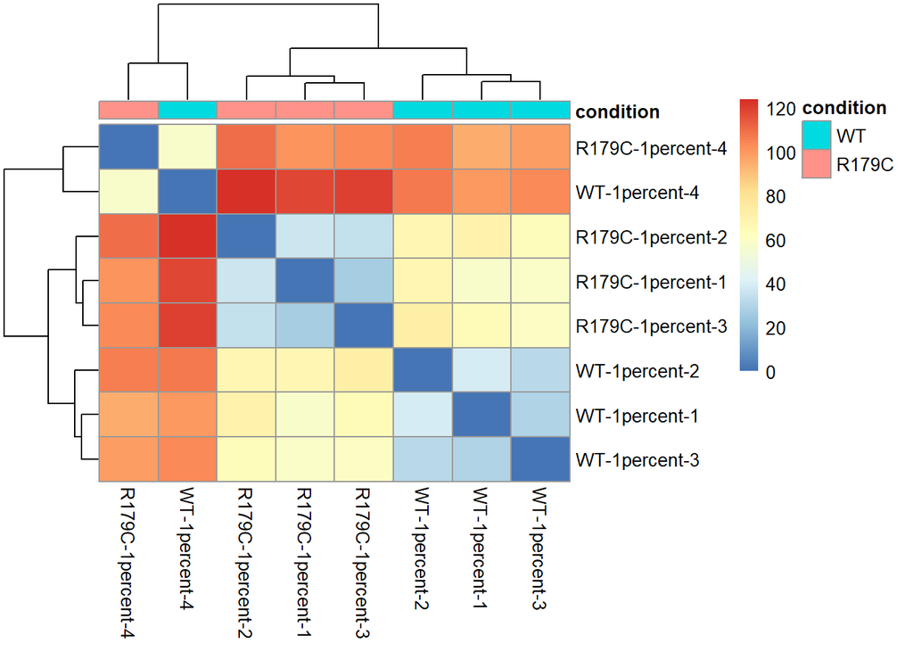

```r
# Sample distance heatmap
d <- dist(t(assay(vsd_4rep)))
pheatmap(as.matrix(d), annotation_col=as.data.frame(colData(dds_4rep)[,"condition",drop=FALSE]))
```

## Check replicate

since the fourth replicate is from another dataset the following chunk is designed to check if the batch effect got handle correctly

```
## using ntop=500 top features by variance
```

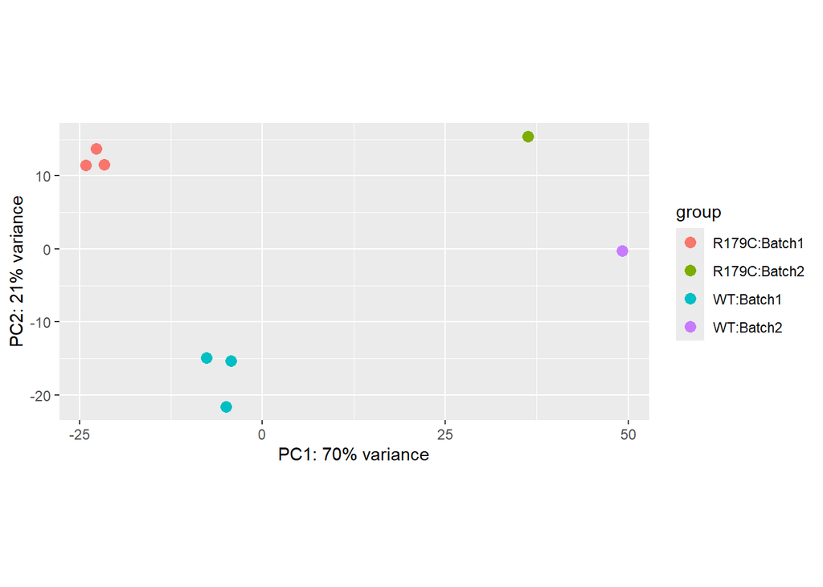

```r
plotPCA(vsd_4rep, intgroup=c("condition","batch"))
```

```r
sample_info_clean_4rep<- sample_info_4rep %>% filter(condition %in% c("R179C", "WT"))
```

since the batch effect still exist check

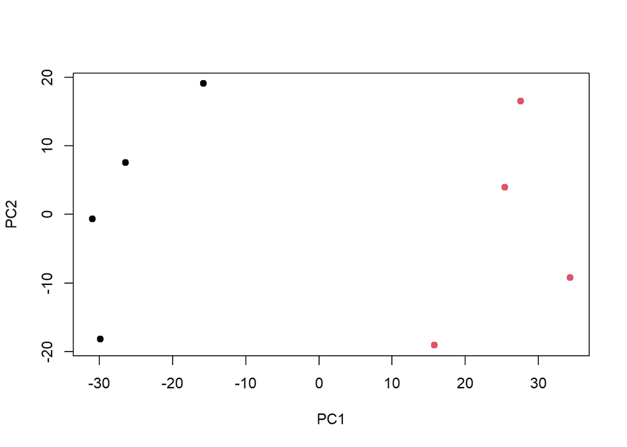

```r
library(limma)
expr_corrected <- removeBatchEffect(assay(vsd_4rep), batch=sample_info_clean_4rep$batch)

# PCA on corrected data
pca_corrected <- prcomp(t(expr_corrected))
plot(pca_corrected$x[,1:2], col=as.factor(sample_info_clean_4rep$condition), pch=19)
```

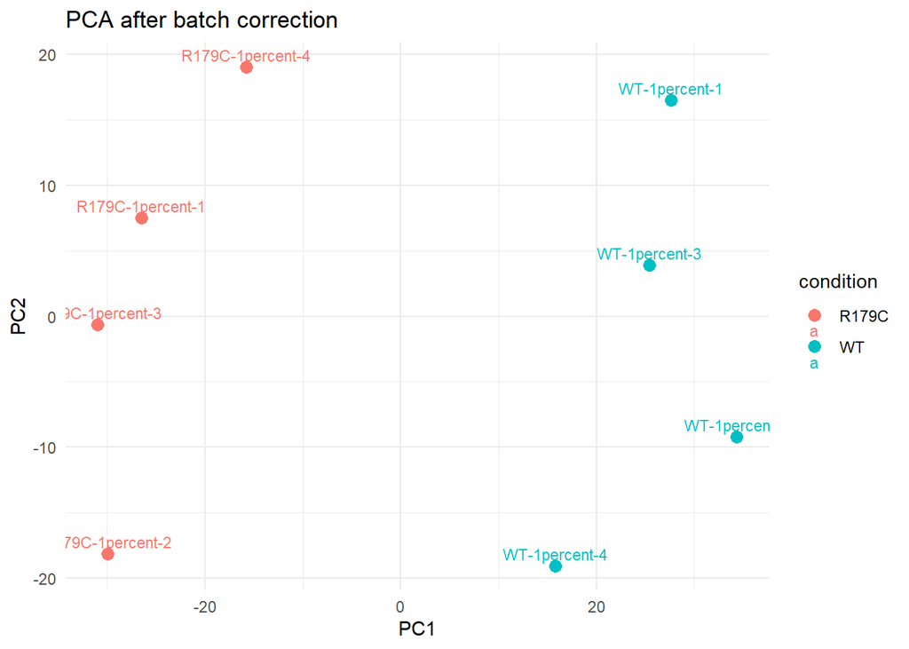

```r
library(ggplot2)

# Run PCA on corrected expression matrix (samples as columns)
pca <- prcomp(t(expr_corrected))  # or use removeBatchEffect output

# Build data frame for plotting
pca_df <- as.data.frame(pca$x[, 1:2])  # PC1 and PC2
pca_df$sample <- rownames(pca_df)
pca_df$condition <- sample_info_clean_4rep$condition[match(pca_df$sample, sample_info_clean_4rep$sampleName)]

# Plot with labels
ggplot(pca_df, aes(x=PC1, y=PC2, color=condition, label=sample)) +
  geom_point(size=3) +
  geom_text(vjust=-0.5, size=3) +
  theme_minimal() +
  labs(title="PCA after batch correction", x="PC1", y="PC2")
```

## Heatmap of top variable genes after batch correction

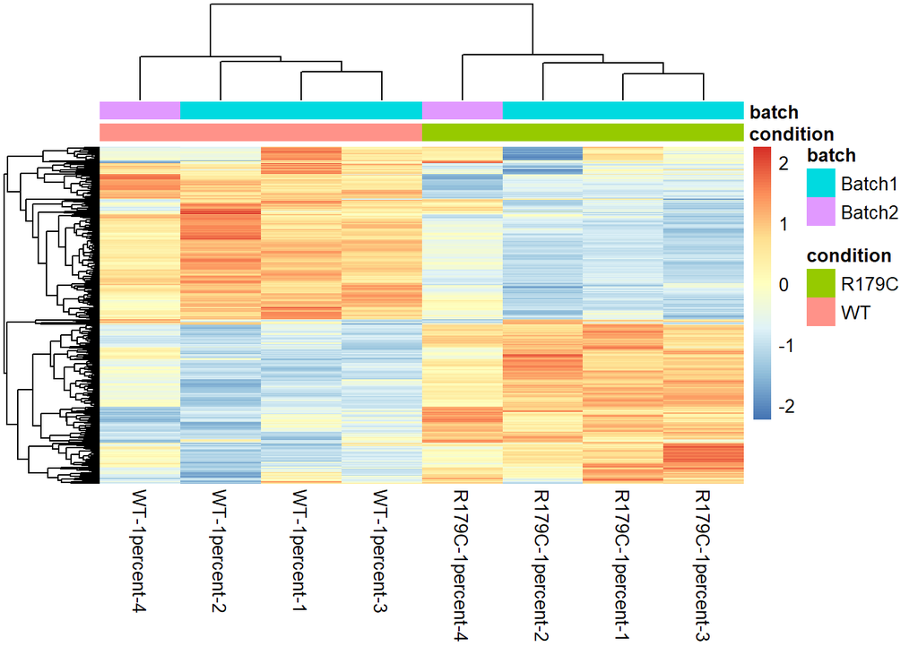

```r
topVarGenes <- head(order(rowVars(expr_corrected), decreasing=TRUE), 500)

annotation <- data.frame(
  condition = sample_info_clean_4rep$condition,
  batch = sample_info_clean_4rep$batch
)
rownames(annotation) <- sample_info_clean_4rep$sampleName

pheatmap(expr_corrected[topVarGenes, ],
         annotation_col = annotation,
         show_rownames = FALSE,
         clustering_distance_rows = "euclidean",
         clustering_distance_cols = "euclidean",
         clustering_method = "complete",
         scale = "row")
```

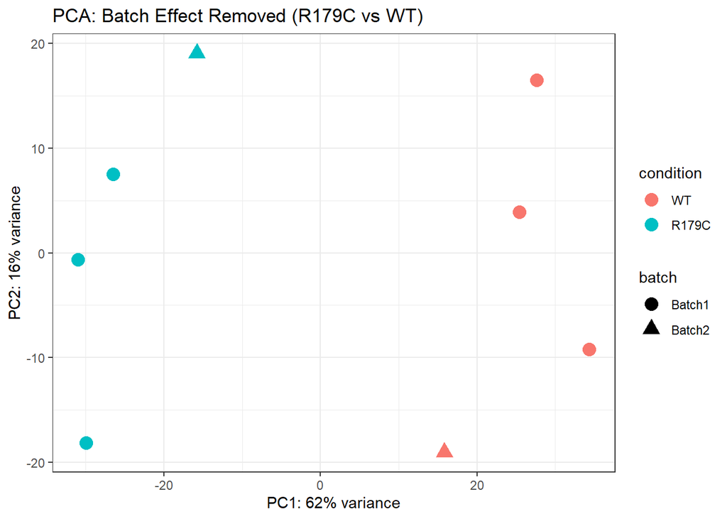

```r
# 1. Ensure you have the corrected expression from earlier
library(limma)

# 2. Run Principal Component Analysis (PCA) on the corrected matrix
pca_corrected <- prcomp(t(expr_corrected))

# 3. Prepare data for ggplot
pca_df <- as.data.frame(pca_corrected$x)
pca_df$condition <- vsd_4rep$condition
pca_df$batch <- vsd_4rep$batch

# Calculate variance percentages for the axes
percentVar <- round(100 * (pca_corrected$sdev^2 / sum(pca_corrected$sdev^2)))

# 4. Plot the corrected version
ggplot(pca_df, aes(PC1, PC2, color = condition, shape = batch)) +
  geom_point(size = 4) +
  xlab(paste0("PC1: ", percentVar[1], "% variance")) +
  ylab(paste0("PC2: ", percentVar[2], "% variance")) +
  ggtitle("PCA: Batch Effect Removed (R179C vs WT)") +
  theme_bw()
```

## Heatmap of top variable genes after batch correction

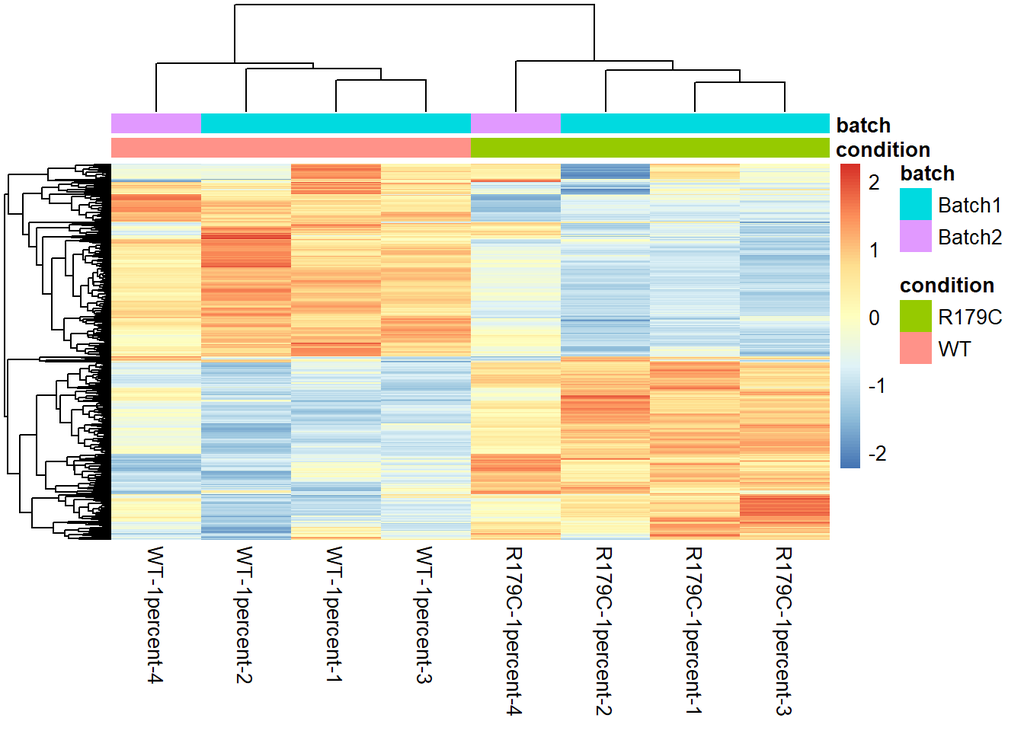

```r
topVarGenes <- head(order(rowVars(expr_corrected), decreasing=TRUE), 500)

annotation <- data.frame(
  condition = sample_info_clean_4rep$condition,
  batch = sample_info_clean_4rep$batch
)
rownames(annotation) <- sample_info_clean_4rep$sampleName

pheatmap(expr_corrected[topVarGenes, ],
         annotation_col = annotation,
         show_rownames = FALSE,
         clustering_distance_rows = "euclidean",
         clustering_distance_cols = "euclidean",
         clustering_method = "complete",
         scale = "row")
```

### R179C vs wildType

```r
sig_R179C_vs_WT_4rep<- subset(res_R179C_vs_WT_4rep, padj < 0.05
                         & abs(log2FoldChange) > 1)
sig_R179C_vs_WT_4rep<- as.data.frame(sig_R179C_vs_WT_4rep[order(sig_R179C_vs_WT_4rep$log2FoldChange, decreasing = T),])
nrow(sig_R179C_vs_WT_4rep)
```

```
## [1] 1264
```

```r
head(sig_R179C_vs_WT_4rep, 10)
```

```
##            baseMean log2FoldChange     lfcSE     stat       pvalue         padj
## AI838599  54.791368       7.025175 0.8777725 8.003412 1.210184e-15 2.659984e-13
## Palmd     53.280012       7.019367 1.0424451 6.733560 1.655610e-11 1.469174e-09
## Cntnap4   10.961523       6.757029 1.1998616 5.631507 1.786417e-08 7.687514e-07
## Cpxm2     16.216141       6.593059 1.1165911 5.904631 3.534360e-09 1.809871e-07
## Wt1       21.623886       6.297960 1.1705238 5.380463 7.429463e-08 2.595226e-06
## Sfta3.ps   6.360929       6.254547 1.4361649 4.355034 1.330463e-05 2.179854e-04
## Mx1       17.714880       6.240644 1.2218879 5.107379 3.266585e-07 9.115177e-06
## Fndc1     60.039740       6.127525 1.1147206 5.496915 3.864923e-08 1.512826e-06
## Moxd1    922.390174       6.043205 0.8058387 7.499274 6.417233e-14 9.355408e-12
## Lrrc3b     4.160359       5.993904 1.3173370 4.550016 5.364192e-06 9.940105e-05
```

```r
write.csv(as.data.frame(sig_R179C_vs_WT_4rep), "./sig_R179C_vs_WT_4rep.csv")
```

## Create MA & volcano plot

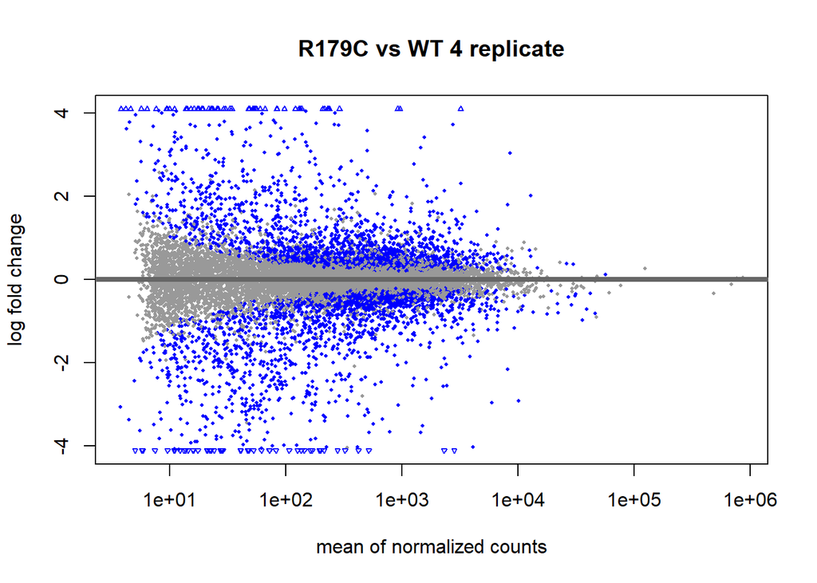

```r
DESeq2::plotMA(res_R179C_vs_WT_4rep, main = "R179C vs WT 4 replicate")
```

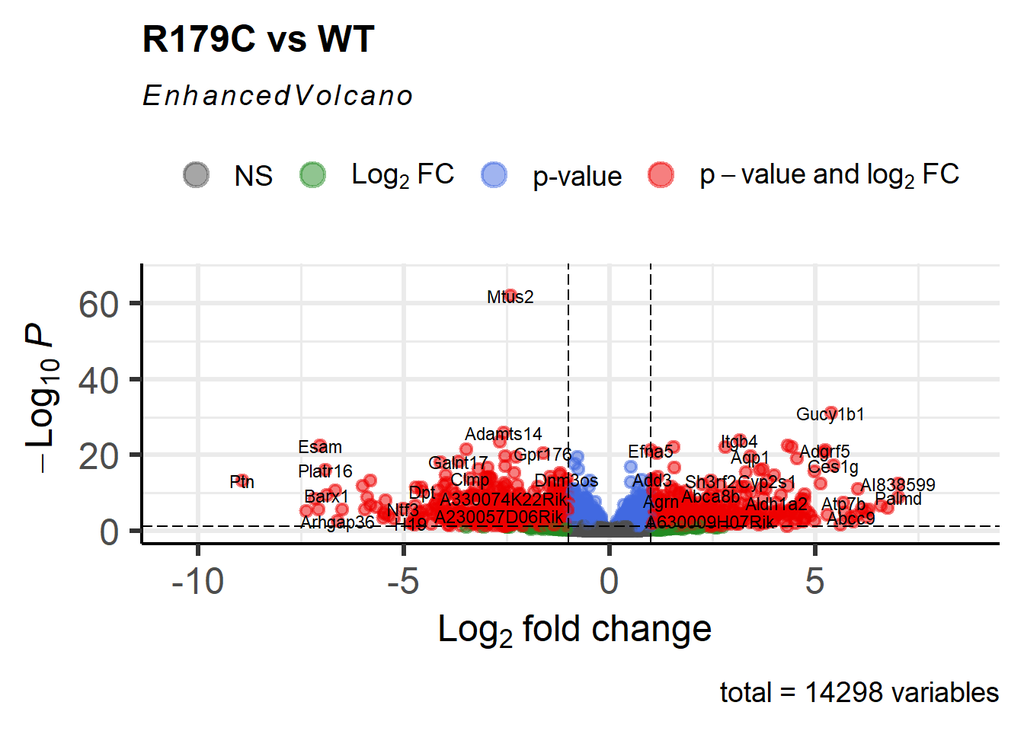

```r
library(EnhancedVolcano)

EnhancedVolcano(res_R179C_vs_WT_4rep,
                lab = rownames(res_R179C_vs_WT_4rep),   # gene labels
                x = 'log2FoldChange',              # x-axis: fold change
                y = 'padj',                        # y-axis: adjusted p-value
                title = 'R179C vs WT',             # plot title
                pCutoff = 0.05,                    # significance threshold
                FCcutoff = 1.0,                    # fold change threshold
                pointSize = 2.0,                   # point size
                labSize = 3.0)                     # label size
```

## plot count example

```r
# 1. Subset the dds object to the 8 samples (4 vs 4)
# This removes the TGFb samples from the counts and metadata
dds_subset_4rep <- dds_4rep[, dds_4rep$condition %in% c("R179C", "WT")]

# 2. Drop the 'WT-TGFb' level so it doesn't appear in your plots
dds_subset_4rep$condition <- droplevels(dds_subset_4rep$condition)

# 3. CRITICAL: Re-run the DESeq estimation
# This ensures the size factors (normalization) are based ONLY on these 8 samples
dds_subset_4rep <- DESeq(dds_subset_4rep)
```

```
## found already estimated dispersions, replacing these
```

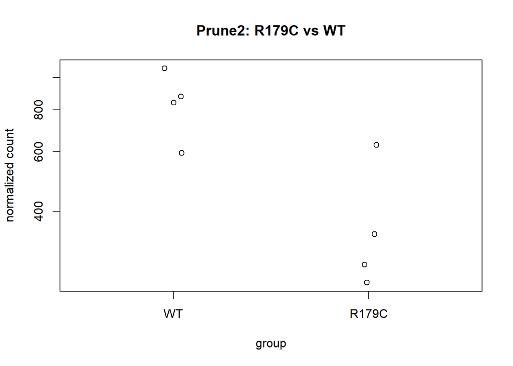

```r
# 4. Plot individual gene counts (e.g., Acta2)
plotCounts(dds_subset_4rep, gene = "Prune2", intgroup = "condition", main = "Prune2: R179C vs WT")
```

#### R179C vs WT separated for upregulated and downregulated genes

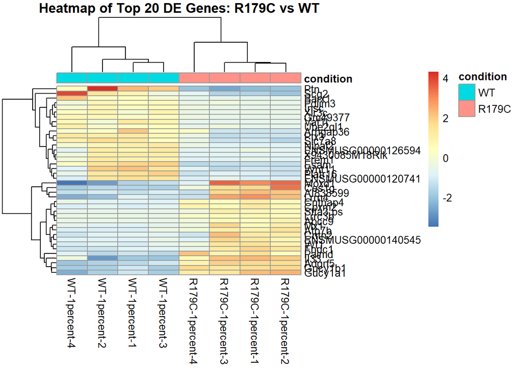

```r
# R179C upregulated genes
#r179c_up <- subset(res_R179C_vs_WT, log2FoldChange > 1 & padj < 0.05)
#top20_R179C <- head(rownames(r179c_up[order(r179c_up$padj), ]), 20)
top20_R179C_4rep <- head(rownames(sig_R179C_vs_WT_4rep), 20)

# WT upregulated genes
#wt_up <- subset(res_R179C_vs_WT, log2FoldChange < -1  & padj < 0.05)
#top20_WT <- head(rownames(wt_up[order(wt_up$padj), ]), 20)

# Already filtered for padj < 0.05 and |log2FC| > 1
sig_R179C_vs_WT_WT_4rep <- sig_R179C_vs_WT_4rep[order(sig_R179C_vs_WT_4rep$log2FoldChange), ]
top20_WT_4rep <- head(rownames(sig_R179C_vs_WT_WT_4rep), 20)

# Combine gene set
combined_genes <- c(top20_R179C_4rep, top20_WT_4rep)

# Subset samples to R179C and WT only
selected_samples <- colData(dds_4rep)$condition %in% c("R179C", "WT")

mat_combined <- assay(vst(dds_4rep))[combined_genes, selected_samples]
mat_combined <- mat_combined - rowMeans(mat_combined)

annotation <- as.data.frame(colData(dds_4rep)[selected_samples, "condition", drop=FALSE])

pheatmap(mat_combined,
         annotation_col = annotation,
         cluster_rows = TRUE,
         cluster_cols = TRUE,
         show_rownames = TRUE,
         main = "Heatmap of Top 20 DE Genes: R179C vs WT")
```

## pathway analysis function

```r
suppressMessages({
  library(clusterProfiler)
  library(ReactomePA)
  library(org.Mm.eg.db)
  library(ggplot2)
  library(openxlsx)
})

Pathway_Enrich <- function(sig_gene_list,
                           condition = "Sample",
                           method = c("KEGG", "Reactome"),
                           p_cut = 0.05,
                           showCategory = 10,
                           output_prefix = "Pathway") {

  method <- match.arg(method)  # restrict to KEGG or Reactome

  message(paste0("Running ", method, " enrichment for ", condition, " ..."))

  # ---- Convert gene symbols to Entrez IDs
  gene_symbols <- rownames(sig_gene_list)
  entrez_ids <- suppressMessages(
    bitr(gene_symbols, fromType = "SYMBOL", toType = "ENTREZID", OrgDb = org.Mm.eg.db)
  )

  if (is.null(entrez_ids) || nrow(entrez_ids) == 0) {
    warning("No valid Entrez IDs found for enrichment.")
    return(NULL)
  }

  # ---- Run enrichment analysis
  enrich_res <- switch(
    method,
    KEGG = suppressMessages(
      enrichKEGG(gene = entrez_ids$ENTREZID,
                 organism = "mmu",
                 pvalueCutoff = p_cut)
    ),
    Reactome = suppressMessages(
      enrichPathway(gene = entrez_ids$ENTREZID,
                    organism = "mouse",
                    pvalueCutoff = p_cut)
    )
  )

  if (is.null(enrich_res) || nrow(as.data.frame(enrich_res)) == 0) {
    message("No significant enrichment found.")
    return(NULL)
  }

  # ---- Plot results
  print(
    dotplot(enrich_res, showCategory = showCategory) +
      ggtitle(paste(method, "Pathway Enrichment -", condition))
  )

  # ---- Convert to readable format (add gene symbols)
  readable_res <- suppressMessages(
    setReadable(enrich_res, OrgDb = org.Mm.eg.db, keyType = "ENTREZID")
  )

  result_df <- as.data.frame(readable_res)

  # ---- Save output to Excel
  output_file <- paste0(output_prefix, "_", condition, "_", method, "_pathway.xlsx")
  openxlsx::write.xlsx(result_df, output_file, overwrite = TRUE)
  message(paste("Saved:", output_file))

  return(result_df)
}
```

```r
# Run KEGG for R179C
R179C_KEGG_4rep<- Pathway_Enrich(sig_R179C_vs_WT_4rep, condition = "R179C", method = "KEGG")
```

```
## Running KEGG enrichment for R179C ...
```

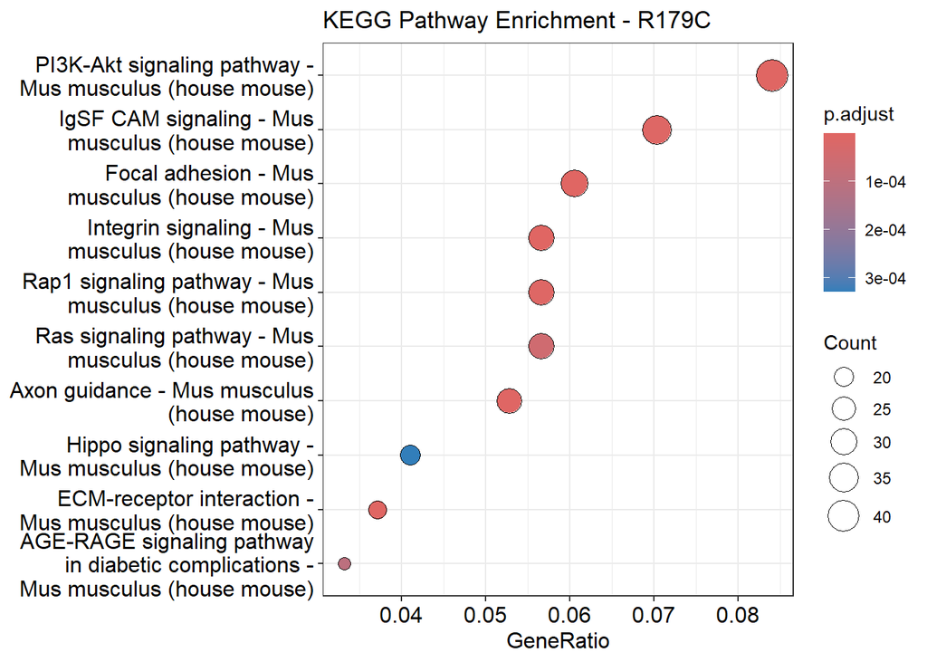

```
## Saved: Pathway_R179C_KEGG_pathway.xlsx
```

```r
R179C_KEGG_4rep
```

[output not shown]

[output cut: 337 more lines]

```
## mmu04024    20
## mmu01522    11
## mmu05145    12
## mmu04370     8
## mmu05207    20
## mmu04371    14
## mmu04350    12
## mmu05218     9
## mmu04540    10
## mmu04725    12
## mmu04970    10
## mmu03250     8
## mmu04620    11
## mmu05100     9
## mmu05418    14
```

```r
# Run Reactome for R179C
R179C_Reactome_4rep<- Pathway_Enrich(sig_R179C_vs_WT_4rep, condition = "R179C", method = "Reactome")
```

```
## Running Reactome enrichment for R179C ...
```

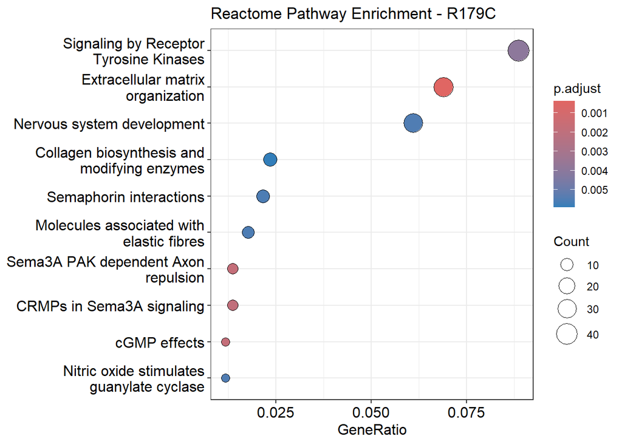

```
## Saved: Pathway_R179C_Reactome_pathway.xlsx
```

```r
R179C_Reactome_4rep
```

[output not shown]

[output cut: 75 more lines]

```
## R-MMU-422475     30
## R-MMU-399955      5
## R-MMU-216083     13
## R-MMU-418346     13
## R-MMU-1566948     9
## R-MMU-8948216     9
## R-MMU-5173214     8
## R-MMU-1442490    10
## R-MMU-3000157     5
## R-MMU-3000171     8
## R-MMU-194138     15
## R-MMU-1474290    12
## R-MMU-2022090     9
## R-MMU-418555     17
## R-MMU-381426     16
```

## Pathway analysis for GO Pathway analysis

## Function convert enrichment result to readable gene symbols

```r
library(clusterProfiler)
library(org.Mm.eg.db)

covert_entrez_to_symbols<- function(enrichment_result){
  if(!is.null(enrichment_result) &&
     nrow(enrichment_result)> 0){
    enrichment_df<- as.data.frame(enrichment_result)

    #Conver Entrez IDs to gene Symbols
    enrichment_df$GeneSymvols<-
      sapply(strsplit(enrichment_df$geneID, "/"), function(entrez_list){
       mapped_genes<- bitr(entrez_list, fromType = "ENTREZID", toType = "SYMBOL", OrgDb = org.Mm.eg.db)
       paste(mapped_genes$SYMBOL, collapse = ", ")
      })
    return(enrichment_df)
  } else {
    return(NULL)
  }

}
```

### go term for portable gene list

Biological Process (BP): This domain encompasses series of molecular events or functions, representing larger biological objectives that are accomplished by the concerted action of multiple molecular activities.

Molecular Function (MF): This domain describes the activities of individual gene products at the molecular level, such as catalyzing chemical reactions or binding specific chemicals or macromolecules.

Cellular Component (CC): This domain refers to the parts of a cell, including subcellular structures, macromolecular complexes, and the extracellular environment where gene products are located.

```r
GO_Res <- function(sig_gene_list,
                   p_cut = 0.05,
                   organism = "mouse") {
  # --- Step 1: Load OrgDb based on organism
  if (organism == "mouse") {
    OrgDb <- org.Mm.eg.db
  } else if (organism == "human") {
    OrgDb <- org.Hs.eg.db
  } else {
    stop("Unsupported organism. Use 'mouse' or 'human'.")
  }

  # --- Step 2: Prepare gene IDs
  gene_symbols <- rownames(sig_gene_list)
  entrez_ids <- bitr(gene_symbols,
                     fromType = "SYMBOL",
                     toType = "ENTREZID",
                     OrgDb = OrgDb)

  # Filter valid Entrez IDs only
  entrez_ids <- entrez_ids[!is.na(entrez_ids$ENTREZID) & entrez_ids$ENTREZID != "", ]

  if (is.null(sig_gene_list) || nrow(entrez_ids) == 0) {
    message("No valid gene list or unsupported organism.")
    return(NULL)
  }

  # --- Step 3: Define helper function for enrichment and table generation
  run_GO <- function(ont) {
    result <- enrichGO(gene = entrez_ids$ENTREZID,
                       OrgDb = OrgDb,
                       ont = ont,
                       pvalueCutoff = p_cut,
                       readable = TRUE)
    if (is.null(result) || nrow(as.data.frame(result)) == 0) {
      return(list(result = NULL, df = NULL, expanded = NULL))
    }

    df <- as.data.frame(result)

    # Expand geneID column into individual genes
    expanded <- df %>%
      dplyr::select(ID, Description, geneID) %>%
      tidyr::separate_rows(geneID, sep = "/") %>%
      dplyr::distinct(geneID, .keep_all = TRUE)

    # Print summary
    print(dotplot(result) + ggtitle(paste("GO", ont, "Enrichment")))
    print(df)

    return(list(result = result, df = df, expanded = expanded))
  }

  # --- Step 4: Run GO enrichment for BP, MF, CC
  go_bp <- run_GO("BP")
  go_mf <- run_GO("MF")
  go_cc <- run_GO("CC")

  # --- Step 5: Combine into a nested return list
  GO_out <- list(
    Biological_Process = go_bp,
    Molecular_Function = go_mf,
    Cellular_Component = go_cc
  )

  message("GO analysis completed successfully.")
  return(GO_out)
}
```